# ASSIGNMENT

Nakibuuka Harriet 2023/HD07/3372U

2023-11-06

# SECTION A: Data Exploration 1

### Read the metaFile.csv file into your R sessions and perform the following operations.

```r
library(knitr)
df <- read.csv("/Users/HP/Desktop/MSBT LECTURE NOTES/Bioconductor and R/Assignment/metaFile.csv")
head(df)
```

|  | sample_id | Participant | Treatment |
| --- | --- | --- | --- |
| 1 | sample_1 | C | 4 |
| 2 | sample_2 | B | 3 |
| 3 | sample_3 | B | 2 |
| 4 | sample_4 | C | 1 |
| 5 | sample_5 | C | 3 |
| 6 | sample_6 | A | 4 |

```r
## kable(head(df))
knitr::kable(head(df))
```

| sample_id | Participant | Treatment |
| --- | --- | --- |
| sample_1 | C | 4 |
| sample_2 | B | 3 |
| sample_3 | B | 2 |
| sample_4 | C | 1 |
| sample_5 | C | 3 |
| sample_6 | A | 4 |

```r
## i. Return the number of variables/columns and records/rows

ncol(df)
```

```
## [1] 3
```

```r
nrow(df)
```

```
## [1] 50
```

```r
## ii. Count the number of samples which were obtained for each level of treatment
library(tidyverse)
df %>%
  group_by(Treatment) %>%
  summarise(count = n())
```

| Treatment | count |
| --- | --- |
| 0 | 9 |
| 1 | 10 |
| 2 | 10 |
| 3 | 11 |
| 4 | 10 |

```r
## iii. Count the number of samples which were obtained for each participant

df %>%
  group_by(Participant) %>%
  summarise(count = n())
```

| Participant | count |
| --- | --- |
| A | 15 |
| B | 17 |
| C | 18 |

```r
## iv. Extract records for samples obtained at treatment levels 0,2 and 4

subset(df, Treatment %in% c(0, 2, 4))
```

|  | sample_id | Participant | Treatment |
| --- | --- | --- | --- |
| 1 | sample_1 | C | 4 |
| 3 | sample_3 | B | 2 |
| 6 | sample_6 | A | 4 |
| 7 | sample_7 | B | 0 |
| 9 | sample_9 | B | 4 |
| 10 | sample_10 | C | 0 |
| 11 | sample_11 | A | 2 |
| 14 | sample_14 | C | 2 |
| 15 | sample_15 | A | 0 |
| 16 | sample_16 | C | 4 |

[output cut: 19 more lines]

```r
## v. Extract records for samples obtained from participants A and C

subset(df, Participant %in% c("A", "C"))
```

|  | sample_id | Participant | Treatment |
| --- | --- | --- | --- |
| 1 | sample_1 | C | 4 |
| 4 | sample_4 | C | 1 |
| 5 | sample_5 | C | 3 |
| 6 | sample_6 | A | 4 |
| 8 | sample_8 | A | 1 |
| 10 | sample_10 | C | 0 |
| 11 | sample_11 | A | 2 |
| 12 | sample_12 | A | 3 |
| 14 | sample_14 | C | 2 |
| 15 | sample_15 | A | 0 |

[output cut: 23 more lines]

```r
## vi. Count the number of samples under each participant groups per treatment level
df %>%
  group_by(Participant, Treatment, .drop = FALSE) %>%
  summarise(n = n(), .groups = 'drop_last') %>%
  pivot_wider(names_from = Treatment, values_from = n, values_fill = 0)
```

| Participant | 0 | 1 | 2 | 3 | 4 |
| --- | --- | --- | --- | --- | --- |
| A | 3 | 3 | 3 | 3 | 3 |
| B | 3 | 3 | 4 | 4 | 3 |
| C | 3 | 4 | 3 | 4 | 4 |

```r
# or

table(df$Participant, df$Treatment)
```

```
##
##     0 1 2 3 4
##   A 3 3 3 3 3
##   B 3 3 4 4 3
##   C 3 4 3 4 4
```

## SECTION B: Data Exploration 2

### Import AssignmentFile.csv file and use it to perform the following operations.

```r
library(knitr)
Assignment_File <- read.csv("/Users/HP/Desktop/MSBT LECTURE NOTES/Bioconductor and R/Assignment/AssignmentFile.csv")
head(Assignment_File)
```

|  | samples | Conc1 | Conc2 | Conc3 |
| --- | --- | --- | --- | --- |
| 1 | sample_1 | 5.9380487 | 2.287777 | 3.248762 |
| 2 | sample_2 | 3.3984629 | 4.050884 | 3.235988 |
| 3 | sample_3 | 1.9464752 | 1.291823 | 1.259798 |
| 4 | sample_4 | 1.7504377 | 4.508815 | 2.615356 |
| 5 | sample_5 | 2.9031939 | 2.600606 | 1.666213 |
| 6 | sample_6 | 0.7466299 | 3.521295 | 1.336153 |

```r
knitr::kable(head(Assignment_File))
```

| samples | Conc1 | Conc2 | Conc3 |
| --- | --- | --- | --- |
| sample_1 | 5.9380487 | 2.287777 | 3.248763 |
| sample_2 | 3.3984629 | 4.050885 | 3.235988 |
| sample_3 | 1.9464752 | 1.291823 | 1.259798 |
| sample_4 | 1.7504377 | 4.508815 | 2.615356 |
| sample_5 | 2.9031939 | 2.600606 | 1.666213 |
| sample_6 | 0.7466299 | 3.521295 | 1.336153 |

```r
## i. Return the number of variables/columns and records/rows

ncol(Assignment_File)
```

```
## [1] 4
```

```r
nrow(Assignment_File)
```

```
## [1] 50
```

```r
## ii. Compute the average concentration for each of the concetrations (ie Conc1, Conc2 and Conc3)

mean(Assignment_File$Conc1)
```

```
## [1] 2.23591
```

```r
mean(Assignment_File$Conc2)
```

```
## [1] 2.631801
```

```r
mean(Assignment_File$Conc3)
```

```
## [1] 2.57969
```

```r
## iii. Compute the average Conc for each sample (Hint: Obtain this by taking the mean of
##Conc1, Conc2 and Conc3).

Assignment_File$Concmean <- rowMeans(Assignment_File[2:4])

print(Assignment_File$Concmean)
```

```
##  [1] 3.824863 3.561779 1.499365 2.958203 2.390004 1.868026 2.409794 1.419867
##  [9] 3.306693 2.288922 2.056538 1.599757 2.451226 2.901506 3.258827 1.753767
## [17] 2.443834 2.657674 1.782624 2.034364 1.998999 2.163061 2.544692 2.452164
## [25] 2.092057 3.003388 3.313401 1.765348 1.624170 3.037058 2.448267 2.038269
## [33] 2.833067 1.957261 1.668823 2.192923 2.616311 3.646680 2.841996 2.949213
## [41] 3.229693 2.329251 3.211285 2.842079 2.998275 2.744949 1.683616 2.672564
## [49] 2.434259 2.322598
```

```r
## iv. Extend this data-frame by introducing a new variable say ”Concmean” to
##contain the average Concentration values computed above
Concmean <- Assignment_File$Concmean

dim(Assignment_File)
```

```
## [1] 50  5
```

```r
## v. Obtain the basic statics (min, max, mean, median, quartiles, variance, standard deviation)
##for all the variables including Concmean

summary(Assignment_File)
```

```
##    samples              Conc1             Conc2            Conc3
##  Length:50          Min.   :0.07948   Min.   :0.6856   Min.   :-0.2755
##  Class :character   1st Qu.:1.64835   1st Qu.:1.8380   1st Qu.: 1.8432
##  Mode  :character   Median :2.22227   Median :2.5963   Median : 2.6424
##                     Mean   :2.23591   Mean   :2.6318   Mean   : 2.5797
##                     3rd Qu.:2.72488   3rd Qu.:3.2873   3rd Qu.: 3.1898
##                     Max.   :5.93805   Max.   :4.7706   Max.   : 5.4324
##     Concmean
##  Min.   :1.420
##  1st Qu.:2.035
##  Median :2.446
##  Mean   :2.482
##  3rd Qu.:2.937
##  Max.   :3.825
```

```r
sapply(Assignment_File[,2:5], sd)
```

```
##     Conc1     Conc2     Conc3  Concmean
## 1.0384617 0.9653108 1.1169179 0.6018165
```

```r
sapply(Assignment_File[,2:5], var)
```

```
##     Conc1     Conc2     Conc3  Concmean
## 1.0784026 0.9318250 1.2475056 0.3621831
```

## SECTION C: Data Manipulation and Graphics

```r
library(knitr)
knitr::kable(head(Assignment_File))
```

| samples | Conc1 | Conc2 | Conc3 | Concmean |
| --- | --- | --- | --- | --- |
| sample_1 | 5.9380487 | 2.287777 | 3.248763 | 3.824863 |
| sample_2 | 3.3984629 | 4.050885 | 3.235988 | 3.561779 |
| sample_3 | 1.9464752 | 1.291823 | 1.259798 | 1.499365 |
| sample_4 | 1.7504377 | 4.508815 | 2.615356 | 2.958203 |
| sample_5 | 2.9031939 | 2.600606 | 1.666213 | 2.390004 |
| sample_6 | 0.7466299 | 3.521295 | 1.336153 | 1.868026 |

```r
## i. Remove variables Conc1, Conc2 and Conc3 from the Assignment data-frame
library(dplyr)

Assignment_File <- select(Assignment_File, "samples", "Concmean")


## ii. Combine (merge) information in the two data-frames concentration with metadata
knitr::kable(head(df))
```

| sample_id | Participant | Treatment |
| --- | --- | --- |
| sample_1 | C | 4 |
| sample_2 | B | 3 |
| sample_3 | B | 2 |
| sample_4 | C | 1 |
| sample_5 | C | 3 |
| sample_6 | A | 4 |

```r
df <- rename(df, samples = sample_id)
head(df)
```

|  | samples | Participant | Treatment |
| --- | --- | --- | --- |
| 1 | sample_1 | C | 4 |
| 2 | sample_2 | B | 3 |
| 3 | sample_3 | B | 2 |
| 4 | sample_4 | C | 1 |
| 5 | sample_5 | C | 3 |
| 6 | sample_6 | A | 4 |

```r
Merged_table <- left_join(df, Assignment_File, by = "samples")
print (Merged_table)
```

```
##      samples Participant Treatment Concmean
## 1   sample_1           C         4 3.824863
## 2   sample_2           B         3 3.561779
## 3   sample_3           B         2 1.499365
## 4   sample_4           C         1 2.958203
## 5   sample_5           C         3 2.390004
## 6   sample_6           A         4 1.868026
## 7   sample_7           B         0 2.409794
## 8   sample_8           A         1 1.419867
## 9   sample_9           B         4 3.306693
## 10 sample_10           C         0 2.288922
## 11 sample_11           A         2 2.056538
## 12 sample_12           A         3 1.599757
## 13 sample_13           B         1 2.451226
## 14 sample_14           C         2 2.901506
```

[output cut: 36 more lines]

```r
## iii. Check the size of the combined data-frame and verify it is what is expected
##(Hint: You may want to use the dim() and colnames() and head() functions)

dim(Merged_table)
```

```
## [1] 50  4
```

```r
colnames(Merged_table, do.NULL = TRUE, prefix = "col")
```

```
## [1] "samples"     "Participant" "Treatment"   "Concmean"
```

```r
head(Merged_table)
```

|  | samples | Participant | Treatment | Concmean |
| --- | --- | --- | --- | --- |
| 1 | sample_1 | C | 4 | 3.824863 |
| 2 | sample_2 | B | 3 | 3.561779 |
| 3 | sample_3 | B | 2 | 1.499365 |
| 4 | sample_4 | C | 1 | 2.958203 |
| 5 | sample_5 | C | 3 | 2.390004 |
| 6 | sample_6 | A | 4 | 1.868026 |

```r
## iv. From the combined dataset, extract records for samples for participants B and C
## obtained at treatment levels 2,3 and 4. Assign this to variable “participantsBC”.

ParticipantsBC <- Merged_table %>% filter(Participant %in% c("B", "C"), Treatment %in% c(2, 3, 4))

print(ParticipantsBC)
```

```
##      samples Participant Treatment Concmean
## 1   sample_1           C         4 3.824863
## 2   sample_2           B         3 3.561779
## 3   sample_3           B         2 1.499365
## 4   sample_5           C         3 2.390004
## 5   sample_9           B         4 3.306693
## 6  sample_14           C         2 2.901506
## 7  sample_16           C         4 1.753767
## 8  sample_17           B         3 2.443834
## 9  sample_18           B         2 2.657674
## 10 sample_20           C         3 2.034364
## 11 sample_24           B         4 2.452164
## 12 sample_29           C         2 1.624170
## 13 sample_31           C         4 2.448267
## 14 sample_32           B         3 2.038269
## 15 sample_33           B         2 2.833067
## 16 sample_35           C         3 1.668823
## 17 sample_39           B         4 2.841996
## 18 sample_44           C         2 2.842079
## 19 sample_46           C         4 2.744949
## 20 sample_47           B         3 1.683616
## 21 sample_48           B         2 2.672564
## 22 sample_50           C         3 2.322598
```

```r
## v. Using ”participantsBC” or otherwise, compute the average Concentration for participants
##B and C under treatments 2, 3 and 4. (Hint: Aggregate or group_by function). In this case,
##we expect to get a single Concentration value for each participant for each treatment.

library(dplyr)
library(tidyr)

result_1 <- ParticipantsBC %>%
  group_by(Participant, Treatment) %>%
  summarise(Average_Conc = mean(Concmean))
print(result_1)
```

```
## # A tibble: 6 × 3
## # Groups:   Participant [2]
##   Participant Treatment Average_Conc
##   <chr>           <int>        <dbl>
## 1 B                   2         2.42
## 2 B                   3         2.43
## 3 B                   4         2.87
## 4 C                   2         2.46
## 5 C                   3         2.10
## 6 C                   4         2.69
```

```r
result_2 <- aggregate(cbind(Concmean) ~ Participant + Treatment,
              data = ParticipantsBC,
              FUN = mean)

print(result_2)
```

```
##   Participant Treatment Concmean
## 1           B         2 2.415668
## 2           C         2 2.455918
## 3           B         3 2.431874
## 4           C         3 2.103947
## 5           B         4 2.866951
## 6           C         4 2.692961
```

```r
## vi. Use a for loop to change treatment levels from 0,1,2,3,4 to “very-low”, “low”, “moderate”, “high”, “very-high” respectively on the combined dataset.
Merged_table
```

| samples | Participant | Treatment | Concmean |
| --- | --- | --- | --- |
| sample_1 | C | 4 | 3.824863 |
| sample_2 | B | 3 | 3.561779 |
| sample_3 | B | 2 | 1.499365 |
| sample_4 | C | 1 | 2.958203 |
| sample_5 | C | 3 | 2.390004 |
| sample_6 | A | 4 | 1.868026 |
| sample_7 | B | 0 | 2.409794 |
| sample_8 | A | 1 | 1.419867 |
| sample_9 | B | 4 | 3.306693 |
| sample_10 | C | 0 | 2.288922 |

[output cut: 40 more lines]

```r
  for (c in 1:ncol(Merged_table)){
  for (r in 1:nrow(Merged_table)){
    value <- Merged_table[r, c]
    if (!is.na(value)) {
    if (value == 0){
      Merged_table[r, c] = "Very Low"
    } else if (value == 1){
      Merged_table[r, c] = "Low"
    } else if (value == 2){
      Merged_table[r, c] = "Moderate"
    } else if (value == 3){
      Merged_table[r, c] = "High"
    } else if (value == 4){
      Merged_table[r, c] = "Very High"
    } } } }

Merged_table
```

| samples | Participant | Treatment | Concmean |
| --- | --- | --- | --- |
| sample_1 | C | Very High | 3.824863 |
| sample_2 | B | High | 3.561779 |
| sample_3 | B | Moderate | 1.499365 |
| sample_4 | C | Low | 2.958203 |
| sample_5 | C | High | 2.390004 |
| sample_6 | A | Very High | 1.868026 |
| sample_7 | B | Very Low | 2.409794 |
| sample_8 | A | Low | 1.419867 |
| sample_9 | B | Very High | 3.306693 |
| sample_10 | C | Very Low | 2.288922 |

[output cut: 40 more lines]

```r
## vii. Write a function to change treatment levels from 0,1,2,3,4 to ”very-low”, ”low”,
##”moderate”, ”high”, ”very-high” respectively, use this with sapply() or other appropriate
##function to change treatment variable in combined dataset

# Create a function to map treatment levels to labels

map_treatment_labels_function <- function(x) {
  labels <- ifelse(x==0, "very low",
                   ifelse(x==1, "low",
                   ifelse(x==2, "moderate",
                   ifelse(x==3, "high",
                   ifelse(x==4, "very high", NA)))))
  return(labels)
}


Merged_table <- left_join(df, Assignment_File, by = "samples")

Merged_table$Treatment <- sapply(Merged_table$Treatment, map_treatment_labels_function)

Merged_table$Treatment
```

```
##  [1] "very high" "high"      "moderate"  "low"       "high"      "very high"
##  [7] "very low"  "low"       "very high" "very low"  "moderate"  "high"
## [13] "low"       "moderate"  "very low"  "very high" "high"      "moderate"
## [19] "low"       "high"      "very high" "very low"  "low"       "very high"
## [25] "very low"  "moderate"  "high"      "low"       "moderate"  "very low"
## [31] "very high" "high"      "moderate"  "low"       "high"      "very high"
## [37] "very low"  "low"       "very high" "very low"  "moderate"  "high"
## [43] "low"       "moderate"  "very low"  "very high" "high"      "moderate"
## [49] "low"       "high"
```

```r
## viii. Check and comment on the time taken to perform the above two operations using the
##for loop and sapply(). (Hint: Use system.time() function).

for_loop_timing <- system.time({
 for (c in 1:ncol(Merged_table)){
  for (r in 1:nrow(Merged_table)){
    value <- Merged_table[r, c]
    if (!is.na(value)) {
    if (value == 0){
      Merged_table[r, c] = "Very Low"
    } else if (value == 1){
      Merged_table[r, c] = "Low"
    } else if (value == 2){
      Merged_table[r, c] = "Moderate"
    } else if (value == 3){
      Merged_table[r, c] = "High"
    } else if (value == 4){
      Merged_table[r, c] = "Very High"
    } } } }
})

Merged_table <- left_join(df, Assignment_File, by = "samples")
sapply_timing <- system.time({ Merged_table$Treatment <- sapply(Merged_table$Treatment, map_treatment_labels_function)

})

print(for_loop_timing)
```

```
##    user  system elapsed
##    0.08    0.02    0.09
```

```r
print(sapply_timing)
```

```
##    user  system elapsed
##       0       0       0
```

```r
# The for_loop lags a bit to run as compared to sapply loop

## xi. Using ggplot2 package, produce appropriate graphical representation of the combined
##dataset with the changed treatment levels. You may produce more than one form of plot.
## Export the image(s) as PNG, the plots should at-least have the following; – Legend – Title
## – Axis labels – White background

Merged_table
```

| samples | Participant | Treatment | Concmean |
| --- | --- | --- | --- |
| sample_1 | C | very high | 3.824863 |
| sample_2 | B | high | 3.561779 |
| sample_3 | B | moderate | 1.499365 |
| sample_4 | C | low | 2.958203 |
| sample_5 | C | high | 2.390004 |
| sample_6 | A | very high | 1.868026 |
| sample_7 | B | very low | 2.409794 |
| sample_8 | A | low | 1.419867 |
| sample_9 | B | very high | 3.306693 |
| sample_10 | C | very low | 2.288922 |

[output cut: 40 more lines]

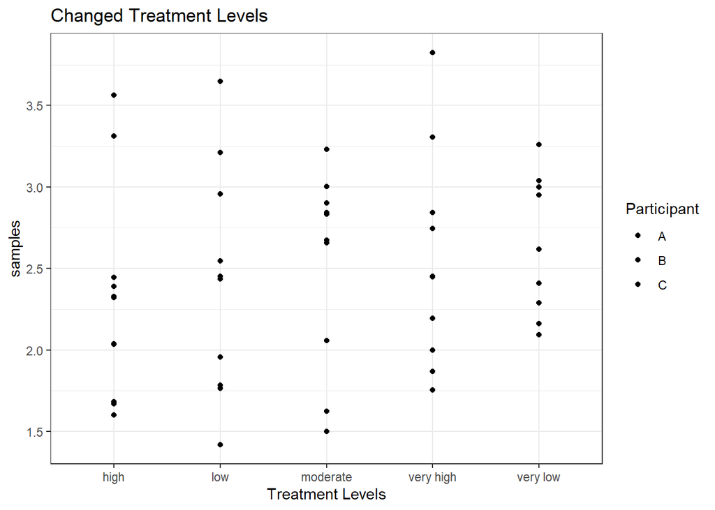

```r
library(ggplot2)


Graphical_Rep_Merged_table1 <- ggplot(data = Merged_table, mapping = aes (x = Treatment, y = Concmean, fill = Participant)) + geom_point() +
labs(title = "Changed Treatment Levels",
x = "Treatment Levels", y = "samples") + theme_bw()

ggsave(file = "plot2.png", Graphical_Rep_Merged_table1)
Graphical_Rep_Merged_table1
```

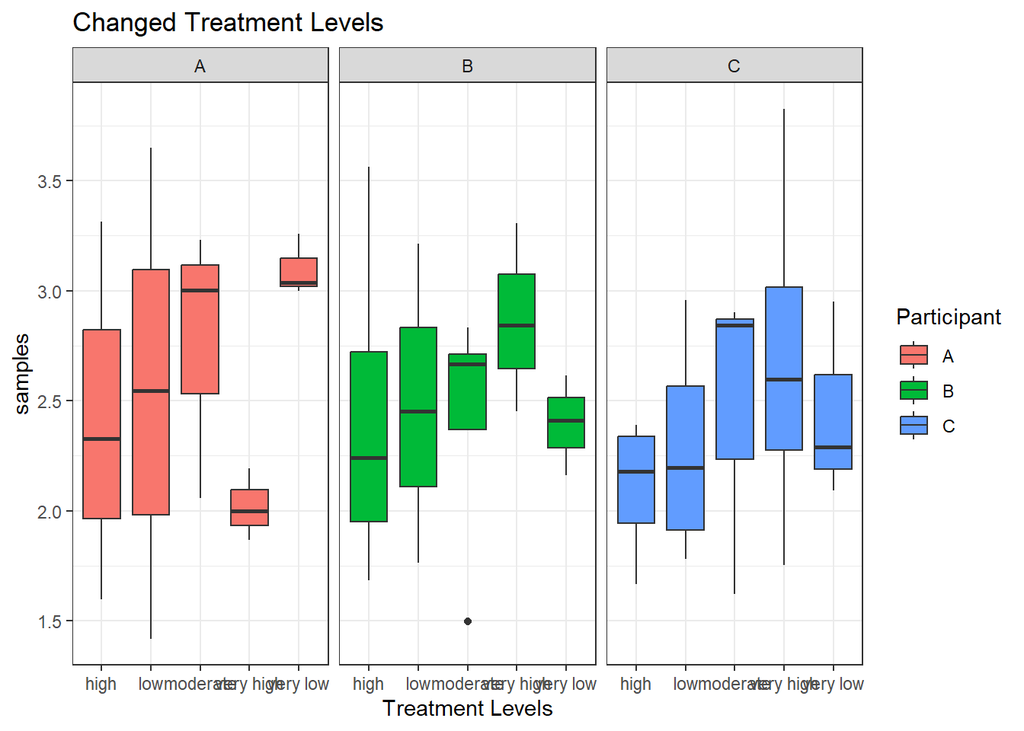

```r
Graphical_Rep_Merged_table2 <- ggplot(data = Merged_table, mapping = aes (x = Treatment, y = Concmean, fill = Participant)) + geom_boxplot() + theme_bw() + facet_wrap(~Participant) + labs(title = "Changed Treatment Levels",
x = "Treatment Levels", y = "samples")

Graphical_Rep_Merged_table2
```

## SECTION D: Classical hypothesis testing and statistical models in R For this section, use the file named statsFile.csv that contains information about participants involved in a study to explore the key predictors of a disease status with only a few variables included for purposes of this exercise. Disease status is encoded into 0 and 1, where 0 means no disease and 1 implies presence of disease. For each participant, six records were taken.

Instructions: • For each part of the exercise, briefly explain choice of the method, technique, or statistical test. This may include assumptions that are required to apply certain techniques • Provide appropriate visualisation • Provide interpretation of the results • Feel free to use up to two approaches whenever you think you have alternatives, you may provide a comparison note of the applied approaches in this case.

```r
library(knitr)
StatsFile <- read.csv("/Users/HP/Desktop/MSBT LECTURE NOTES/Bioconductor and R/Assignment/statsFile.csv")
head(StatsFile)
```

|  | Participants | BMI | BP | Gender | Status | Location |
| --- | --- | --- | --- | --- | --- | --- |
| 1 | P_ 1 | 3.306331 | 1.848332 | Male | 1 | C |
| 2 | P_ 2 | 3.144198 | 1.803189 | Female | 0 | C |
| 3 | P_ 3 | 3.268586 | 1.837923 | Female | 1 | B |
| 4 | P_ 4 | 3.175555 | 1.812009 | Male | 1 | C |
| 5 | P_ 5 | 3.084312 | 1.786221 | Female | 1 | A |
| 6 | P_ 6 | 3.227014 | 1.826389 | Female | 1 | C |

```r
## i. How does BMI relate to BP for the all study participants? (Hint: Correlation, comparison of means and variances for BMI and BP)

cor(StatsFile$BMI,StatsFile$BP)
```

```
## [1] 0.9997509
```

```r
cor.test(StatsFile$BMI, StatsFile$BP)
```

```
##
##  Pearson's product-moment correlation
##
## data:  StatsFile$BMI and StatsFile$BP
## t = 798.75, df = 318, p-value < 2.2e-16
## alternative hypothesis: true correlation is not equal to 0
## 95 percent confidence interval:
##  0.9996895 0.9998001
## sample estimates:
##       cor
## 0.9997509
```

```r
cor.test(StatsFile$BMI, StatsFile$BP, method = "pearson")
```

```
##
##  Pearson's product-moment correlation
##
## data:  StatsFile$BMI and StatsFile$BP
## t = 798.75, df = 318, p-value < 2.2e-16
## alternative hypothesis: true correlation is not equal to 0
## 95 percent confidence interval:
##  0.9996895 0.9998001
## sample estimates:
##       cor
## 0.9997509
```

```r
?cor.test
```

```
## starting httpd help server ... done
```

```r
cov(StatsFile$BMI, StatsFile$BP)
```

```
## [1] 0.01065146
```

```r
cov(StatsFile$BMI, StatsFile$BP) / (sd(StatsFile$BMI) * sd(StatsFile$BP))
```

```
## [1] 0.9997509
```